# Student Performance Analysis

SwimmingBird

Analysis based on synthetic data set.

Source: https://www.kaggle.com/datasets/jayaantanaath/student-habits-vs-academic-performance

```r
require(tidyverse)
require(skimr)
require(ggthemes)
require(corrplot)
filter <- dplyr::filter
df <- read_csv("student_habits_performance.csv", show_col_types = F)
```

Dataset is clean and well organized, no prep required.

Dataset lends itself well to exploratory and regression analysis.

The main outcome variable is exam score, accompanied by a variety of student attribute and behaviour variables.

First, basic check for variation in categorical variables.

```r
df_colnames <- colnames(df)
character_cols <- df_colnames[sapply(df, is.character)]

df_long_character <- df %>%
  pivot_longer(character_cols[-1], names_to = "variable", values_to = "category")
facet_character_labels <- c(
  diet_quality = "Diet Quality",
  extracurricular_participation = "Extracurricualar Participation",
  gender = "Gender",
  internet_quality = "Internet Quality",
  parental_education_level = "Parental Education",
  part_time_job = "Part Time Job"
)

require(colorspace)

ggplot(df_long_character, aes(x = category, fill=category)) +
  geom_bar(color = "black") +
  facet_wrap(~ variable, scales = "free_x", labeller = labeller(variable = facet_character_labels)) +
  guides(fill="none") +
  labs(x=NULL,y=NULL) +
  theme(axis.text.x = element_text(
    angle = 45,
    hjust = 1
  )) +
  scale_fill_discrete_qualitative(palette = "Set2")
```

[output not shown]

Next, basic check for variation in numeric variables.

```r
numeric_cols <- df_colnames[sapply(df, is.numeric)]

df_long_numeric <- df %>%
  pivot_longer(numeric_cols, names_to = "variable", values_to = "value")
facet_numeric_labels <- c(
  age = "Age",
  study_hours_per_day = "Study Hours Per Day",
  social_media_hours = "Social Media Hours",
  netflix_hours = "Netflix Hours",
  attendance_percentage = "Attendance Percentage",
  sleep_hours = "Sleep Hours",
  exercise_frequency = "Exercise Frequency",
  mental_health_rating = "Mental Health Rating",
  exam_score = "Exam Score"
)

ggplot(df_long_numeric, aes(x = value, fill=variable)) +
  geom_histogram(color = "black", bins = 10) +
  facet_wrap(~ variable, scales = "free_x", labeller = labeller(variable = facet_numeric_labels)) +
  labs(x=NULL, y=NULL) +
  guides(fill="none") +
  scale_fill_discrete_qualitative(palette = "Set2")
```

[output not shown]

Pearson’s Correlation plot

```r
corrplot(
  df %>% select(where(is.numeric)) %>% select(sort(names(.))) %>% relocate(exam_score) %>% cor,
  type = "upper",
  diag = F,
  tl.col = "black",
  tl.srt = 45
)
```

[output not shown]

Distance correlation plot

```r
require(dcortools)

corrplot(
  (df %>% select(where(is.numeric)) %>% select(sort(names(.))) %>% relocate(exam_score) %>% as.data.frame() %>% dcmatrix)$dcor,
  type = "upper",
  diag = F,
  tl.col = "black",
  tl.srt = 45
)
```

[output not shown]

The synthetic nature of the dataset is evident for in a realistic setting significant attention would be paid to the joint distribution of behavioural markers like exercise frequency, mental health rating, sleep hours and social media hours and then their effect on study hours per day. As a check we can inspect visually.

```r
require(lattice)

#| fig-width: 10
#| fig-height: 20


cloud(
  mental_health_rating ~ social_media_hours + sleep_hours |
    factor(
      exercise_frequency,
      labels = c("zero", "one", "two", "three", "four", "five", "six")
    ),
  data = df,
  as.table = TRUE,

  scales = list(
    arrows = FALSE,
    x = list(cex = 1),
    y = list(cex = 1),
    z = list(cex = 1)
  ),

  xlab = list("Social media hours", cex =  1.2, rot= 33),
  ylab = list("Sleep hours", cex =  1.2, rot = - 40),
  zlab = list("Mental health rating", cex = 1.2, rot=90),
  layout = c(2,4)
)
```

[output not shown]

Fitting GAM.

```r
require(mgcv)

gam_formula <- reformulate(
  c(character_cols[-1],paste0("s(",numeric_cols[!numeric_cols=="exam_score"],", bs='cr', k = 7)")),
  response = "exam_score"
)

gam_fit <- gam(gam_formula, data = df)
```

```r
summary(gam_fit)
```

[output not shown]

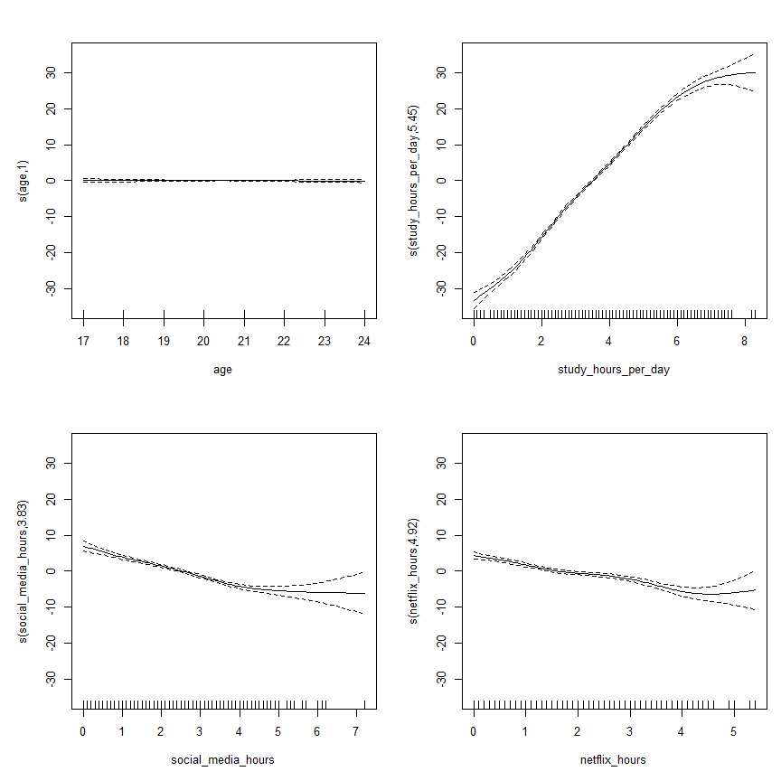

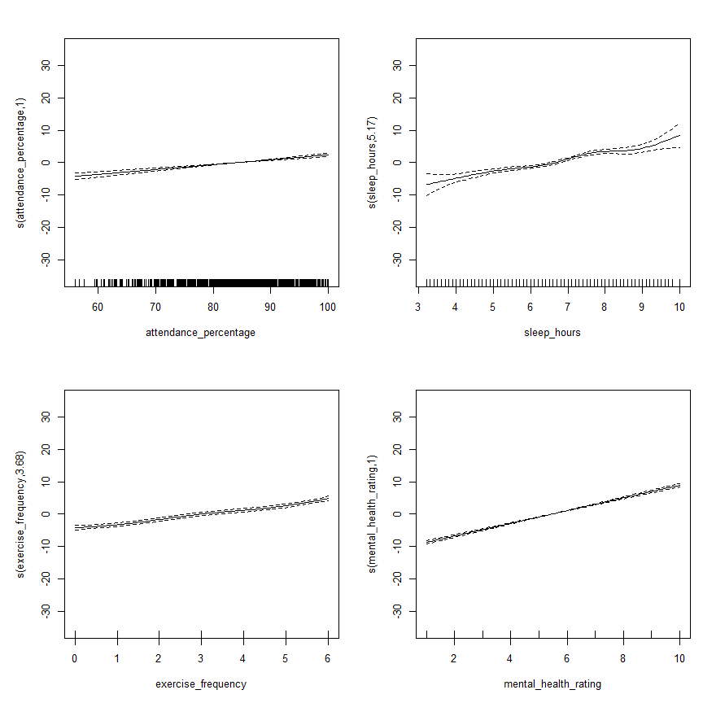

```r
plot(gam_fit, pages= 2, )
```

It is clear the greatest predictor in practical terms is study hours per day for the model finds increase from median to upper percentile study hours to be associated with a 30 mark exam score increase, similarly a 30 mark decrease for a change from median to lower percentile study hours. Rest of numerical behavioral markers are much more modest in their “effect” (in quotations since this is not causal effect), most showing a 5-10 mark sway from median to upper percentile. Importantly, netflix hours and social media hours have an asymmetric “effect” around respective medians, where the positive “effect” on exam scores of reducing their duration extends further, wheres the negative “effect” plateaus quite quickly.

Categorical variables are much less practically significant, mostly attributing to no more than a single mark on exam scores. Their statistical insignificance should not be of interest since that would require presumption of normality or establishing that errors are distributed similarly enough to Gaussian distribution. (test to follow)

For the purpose of reducing the number of model dimensions, we can reduce the set of regressors down to the practically significant numerical variables, fit new gam and employ cross validation to see if the additional variables help predict exam scores any better.

```r
require(rsample)
```

```r
gam_formula_trimmed <- reformulate(
  paste0("s(",numeric_cols[!numeric_cols=="exam_score" & !numeric_cols=="age"],", bs='cr', k=7)"),
  response = "exam_score"
)
gam_fit_trimmed <- gam(
  gam_formula_trimmed, data = df
)
```

```r
summary(gam_fit_trimmed)
```

[output not shown]

Immediately we can notice how the larger and trimmed models both explain about 91% of defiance, i.e. both fit the training data about equally well. We can stop here since we don’t expect overfitting to be an issue with one but not the other, nevertheles let’s proceed with cross validation.

```r
ggplot(
  data = data.frame(
    exam_score=df$exam_score,predicted_value = gam_fit_trimmed$fitted.values)
  ) +
  geom_point(
    aes(
      exam_score,predicted_value,
      color = if_else(
        predicted_value>100| predicted_value < 0,"outside of range","within range"),
      ),
    alpha = .4
    ) +
  geom_hline(yintercept = 100, linetype = 2) +
  scale_color_manual(values = c(
    "outside of range" = "red",
    "within range" = "black")
    ) +
  labs(
    x = "observed Exam Score",
    y = "predicted Exam Score",
    color = "predicted value is"
  )
```

[output not shown]

The simple fix we propose is to manually cap the predicted values.

```r
cap_values_vectorized <- function(v) {
  v <- pmin(v,100)
  v <- pmax(0,v)
  return(v)
}
```

```r
gam_fit_trimmed_fitted_values_capped <- cap_values_vectorized(gam_fit_trimmed$fitted.values)
```

Now we can plot adjusted residuals against trimmed model fitted values.

```r
ggplot(data=data.frame(
  fitted_values = gam_fit_trimmed_fitted_values_capped,
  adjusted_residuals = gam_fit_trimmed_fitted_values_capped - gam_fit_trimmed$y
)) +
  geom_point(aes(fitted_values,adjusted_residuals), alpha = .5) +
  labs(
    x = "capped fitted value",
    y = "residual"
  )
```

[output not shown]

And then test for normality via Jarque-Berra test:

```r
require(tseries)
jarque.bera.test(gam_fit_trimmed_fitted_values_capped - gam_fit_trimmed$y) %>% print()
```

```
    Jarque Bera Test

data:  gam_fit_trimmed_fitted_values_capped - gam_fit_trimmed$y
X-squared = 0.013068, df = 2, p-value = 0.9935
```

Data is synthetic, so the evidence suggests it really is Gaussian noise.

No to decide if the smaller model predicts as well as the larger use cross validation.

```r
generate_kfold_cv_score_gam <- function(formula,data,n=10) {
  folds <- vfold_cv(data,v=n)
  folds_mse <- list()
  for (i in seq(1,n)) {
    model_fit <- gam(formula,data = folds$splits[[i]] %>% analysis())
    model_predicts <- predict(model_fit, newdata = folds$splits[[i]] %>% assessment())
    model_predicts <- cap_values_vectorized(model_predicts)
    resids <- (folds$splits[[i]] %>% assessment())$exam_score - model_predicts
    folds_mse[[i]] = sum(resids^2)
  }
  cv_score <- (folds_mse %>% as.numeric() %>% sum()) / nrow(data)
  return(cv_score)
}
```

```r
print(paste("K-fold cross validation score under full gam specification is", generate_kfold_cv_score_gam(gam_formula,df)%>%signif(3), "."))
```

```
[1] "K-fold cross validation score under full gam specification is 26.8 ."
```

```r
print(paste("K-fold cross validation score under smaller gam specification is", generate_kfold_cv_score_gam(gam_formula_trimmed,df)%>%signif(3), "."))
```

```
[1] "K-fold cross validation score under smaller gam specification is 26.5 ."
```

```r
generate_gam_loocv_score <- function(formula,data) {
  folds <- loo_cv(data)
  resids <- list()
  for (i in seq(1,nrow(data))) {
    model_fit <- gam(formula, data = folds$splits[[i]] %>% analysis())
    model_predicts <- predict(model_fit, newdata = folds$splits[[i]] %>% assessment())
    model_predicts <- cap_values_vectorized(model_predicts)
    resids[[i]] <- (folds$splits[[i]] %>% assessment())$exam_score - model_predicts
  }
  resids <- resids %>% as.numeric()
  cv_score <- resids^2 %>% mean
  return(cv_score)
}
```

```r
loocv_full_spec <- generate_gam_loocv_score(gam_formula, df)
```

```r
loocv_trimmed_spec <- generate_gam_loocv_score(gam_formula_trimmed, df)
```

```r
print(paste("Leave-one-out cross validation score under full gam specification is", loocv_full_spec %>% signif(3), "."))
```

```
[1] "Leave-one-out cross validation score under full gam specification is 26.5 ."
```

```r
print(paste("Leave-one-out cross validation score under smaller gam specification is", loocv_trimmed_spec %>% signif(3), "."))
```

```
[1] "Leave-one-out cross validation score under smaller gam specification is 26.2 ."
```

The smaller gam specification does as well as the full spec regression. This is very encouraging.

Now, it remains to generate the confidence intervals via bootstrap.